# ST5226 Spatial Statistics - Part 1

#### Plot Order for `Polygons` in `SpatialPolygons` object

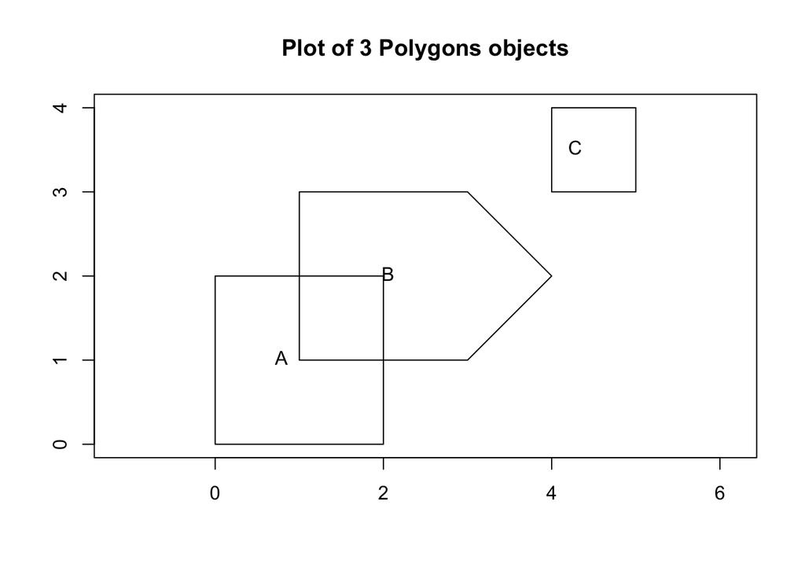

```r
plot(len_3, axes=TRUE, main="Plot of 3 Polygons objects")
text(coordinates(len_3)[,1], # Use coordinates() to retrieve spatial coordinates of
     coordinates(len_3)[,2], c("A", "B", "C"), pos=2) ## Polygons objects
```

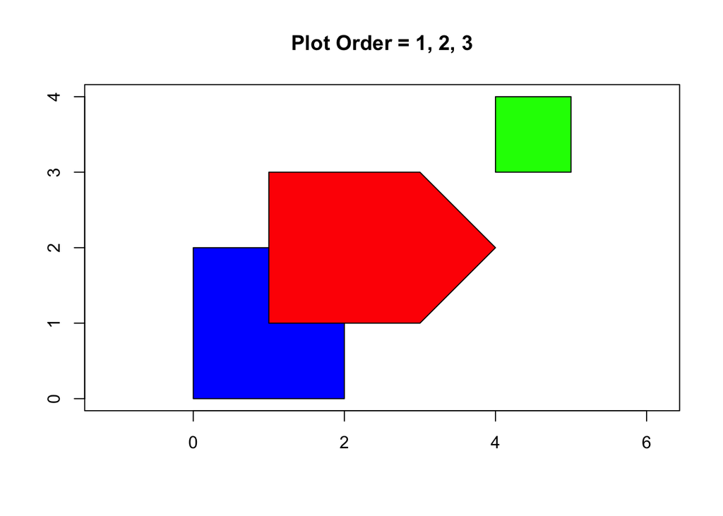

```r
plot(len_3, axes=TRUE, col=c("blue", "red", "green"),main="Plot Order = 1, 2, 3")
```

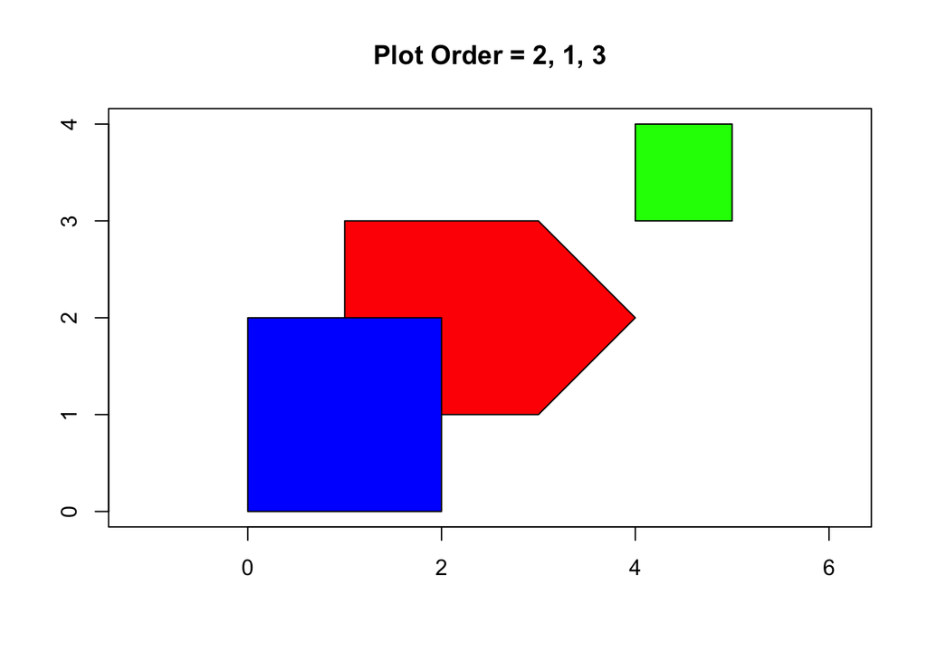

```r
len_3_pO <- SpatialPolygons(list(A, B, C), pO=as.integer(c(2,1,3))) # Changing the plot order with pO arg
plot(len_3_pO, axes=TRUE, col=c("blue", "red", "green"),main="Plot Order = 2, 1, 3")
```

#### Creating holes

- When computing the area of or plotting a polygon all holes are excluded as they are considered exterior to the polygon.
- To specify a `Polygon` as a hole, set `hole=TRUE` and/or `ringDir=−1` (i.e. counter-clockwise).

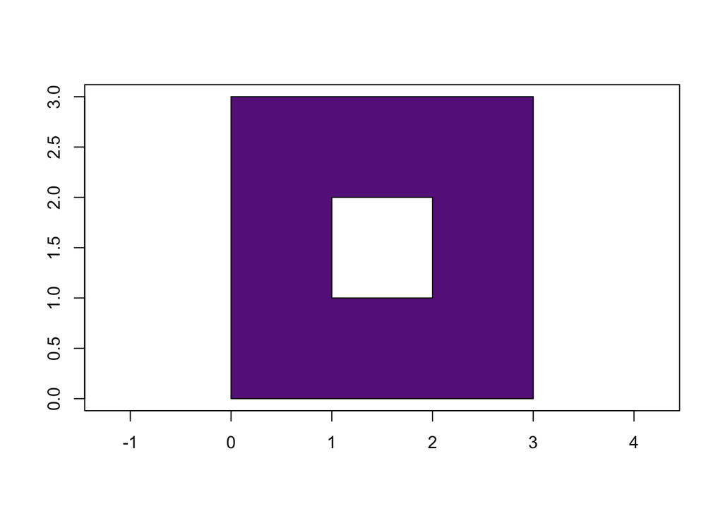

```r
# Initializing Polygon D without holes
D_coords <- matrix(c(0,0,0,3,3,
                     3,3,0,0,0), ncol=2, byrow=TRUE)
D <- Polygon(D_coords, hole=FALSE)

# Initializing Polygon E with hole = TRUE
E_coords <- matrix(c(1,1,1,2,2,
                     2,2,1,1,1), ncol=2, byrow=TRUE)
E <- Polygon(E_coords, hole=TRUE)

DE <- Polygons(list(D,E), "DE")
DE <- SpatialPolygons(list(DE))
plot(DE, col='darkorchid4', axes=TRUE)
```

### `SpatialGrids` Objects

#### Creating a `GridTopology` object

A `GridTopology` object has 3 slots:

- `cellcenter.offset`: Vector coordinates of the center of the cell in the lower left-hand (SW) corner.
- `cellsize`: Vector with cell size in each dimension
- `cells.dim`: Vector with number of cells in the x and y directions.

```r
getClass("GridTopology")
```

```
## Class "GridTopology" [package "sp"]
##
## Slots:
##
## Name:  cellcentre.offset          cellsize         cells.dim
## Class:           numeric           numeric           integer
```

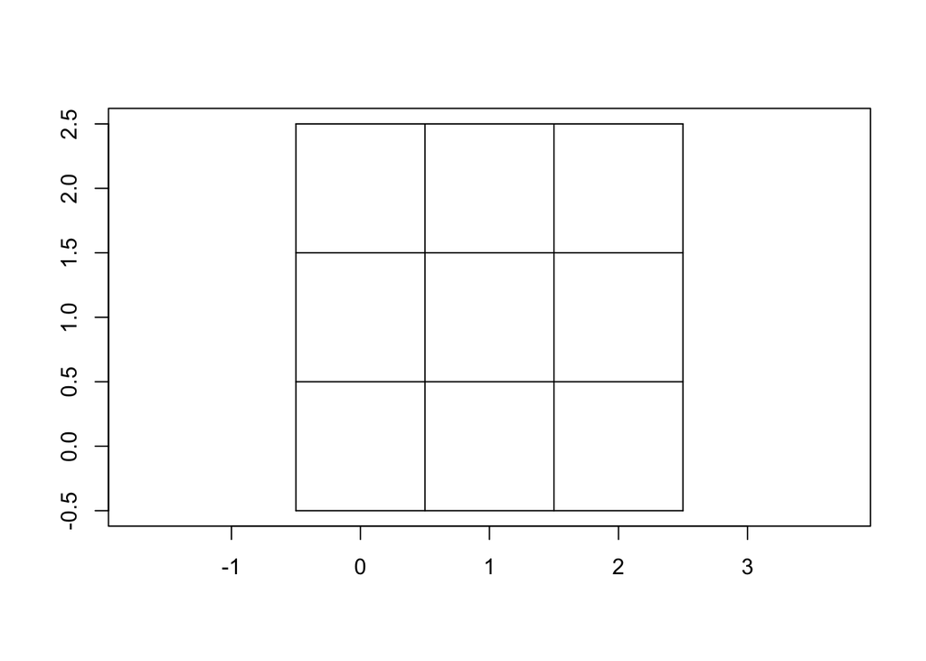

```r
# Initialize a 3 x 3 grid of cell-size 1 x 1 beginning from (0,0) - lower left
g <- GridTopology(c(0,0), c(1,1), c(3,3))
sg <- SpatialGrid(g); plot(sg, axes=TRUE)
```

#### Creating a `SpatialGridDataFrame` object

Suppose we want to add an attribute (numbers 1-9) to each cell of sg.

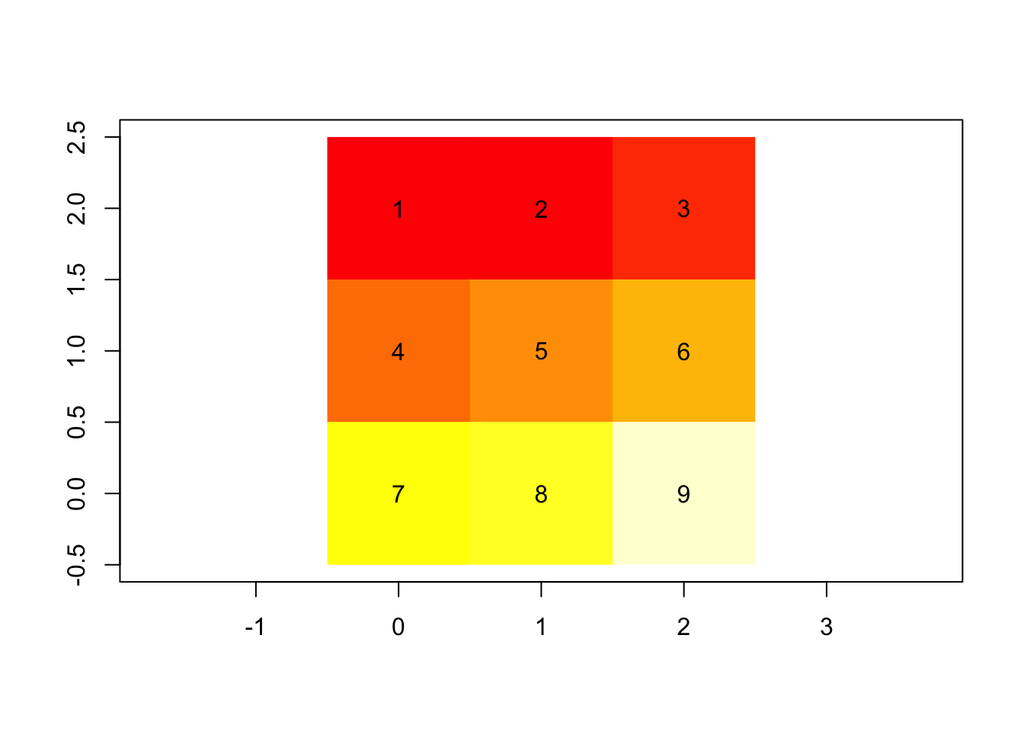

```r
sgd <- SpatialGridDataFrame(sg, data.frame(val=1:9))
image(sgd,axes=TRUE)
cc = coordinates(sgd) # Obtain the coordinates
z = as.character(sgd[["val"]]) # obtain the val attributes from the data slot
text(cc[,1], cc[,2], z)
```

#### Grid Indexing

```r
sgd[1,1] # Top-left most cell
```

```
##   coordinates val
## 1      (0, 2)   1
```

```r
sgd[1:2,2:3] # Cells 2, 3, 5 and 6
```

```
## Object of class SpatialGridDataFrame
## Object of class SpatialGrid
## Grid topology:
##    cellcentre.offset cellsize cells.dim
## s1                 1        1         2
## s2                 1        1         2
## SpatialPoints:
##      s1 s2
## [1,]  1  2
## [2,]  2  2
## [3,]  1  1
## [4,]  2  1
## Coordinate Reference System (CRS) arguments: NA
##
## Data summary:
##    Min. 1st Qu.  Median    Mean 3rd Qu.    Max.
##    2.00    2.75    4.00    4.00    5.25    6.00
```

### Creating `SpatialPixels`

- Pixel objects focus on cells with attribute information and is more memory efficient for sparse data frames

```r
set.seed(1)
is.na(sgd$val) <- sample(9, size=3) # selecting 3 values randomly (9,4,7), set values to NA
sgd$val
```

```
## [1]  1  2  3 NA  5  6 NA  8 NA
```

```r
sp1 <- as(sgd, "SpatialPixelsDataFrame") # Coerce sgd as a SpatialPixelsDataFrame object
coordinates(sp1); sp1$val # Note the removal of 3 cells
```

```
##      s1 s2
## [1,]  0  2
## [2,]  1  2
## [3,]  2  2
## [4,]  1  1
## [5,]  2  1
## [6,]  1  0
```

```
## [1] 1 2 3 5 6 8
```